# Practical Machine Learning Peer Assignment

Arpita Mukherjee

## Overview

Using devices such as Jawbone Up, Nike FuelBand, and Fitbit it is now possible to collect a large amount of data about personal activity relatively inexpensively. These type of devices are part of the quantified self movement – a group of enthusiasts who take measurements about themselves regularly to improve their health, to find patterns in their behavior, or because they are tech geeks. One thing that people regularly do is quantify how much of a particular activity they do, but they rarely quantify how well they do it. In this project, our goal is to use data from accelerometers on the belt, forearm, arm, and dumbell of 6 participants. They were asked to perform barbell lifts correctly and incorrectly in 5 different ways. More information is available from the website here: http://web.archive.org/web/20161224072740/http:/groupware.les.inf.puc-rio.br/har (see the section on the Weight Lifting Exercise Dataset).

Data

The training data for this project are available here:

https://d396qusza40orc.cloudfront.net/predmachlearn/pml-training.csv

The test data are available here:

https://d396qusza40orc.cloudfront.net/predmachlearn/pml-testing.csv

### Downloading data from the link

```r
fileurl <- "https://d396qusza40orc.cloudfront.net/predmachlearn/pml-training.csv"
download.file(fileurl, destfile = "~/Desktop/coursera/data_ml_project.csv", method = "curl")
#list.files("./coursera")
fileurl <- "https://d396qusza40orc.cloudfront.net/predmachlearn/pml-testing.csv"
download.file(fileurl, destfile = "~/Desktop/coursera/test_data_ml_project.csv", method = "curl")
#list.files("./coursera")
```

### Reading training and test dataset

```r
training_data <- read.csv("data_ml_project.csv")
testing_data <- read.csv("test_data_ml_project.csv")
```

Now, lets explore the training dataset

### Exploring Training Dataset

```r
dim(training_data)
```

```
## [1] 19622   160
```

```r
str(training_data)
```

```
## 'data.frame':    19622 obs. of  160 variables:
##  $ X                       : int  1 2 3 4 5 6 7 8 9 10 ...
##  $ user_name               : Factor w/ 6 levels "adelmo","carlitos",..: 2 2 2 2 2 2 2 2 2 2 ...
##  $ raw_timestamp_part_1    : int  1323084231 1323084231 1323084231 1323084232 1323084232 1323084232 1323084232 1323084232 1323084232 1323084232 ...
##  $ raw_timestamp_part_2    : int  788290 808298 820366 120339 196328 304277 368296 440390 484323 484434 ...
##  $ cvtd_timestamp          : Factor w/ 20 levels "02/12/2011 13:32",..: 9 9 9 9 9 9 9 9 9 9 ...
##  $ new_window              : Factor w/ 2 levels "no","yes": 1 1 1 1 1 1 1 1 1 1 ...
##  $ num_window              : int  11 11 11 12 12 12 12 12 12 12 ...
##  $ roll_belt               : num  1.41 1.41 1.42 1.48 1.48 1.45 1.42 1.42 1.43 1.45 ...
##  $ pitch_belt              : num  8.07 8.07 8.07 8.05 8.07 8.06 8.09 8.13 8.16 8.17 ...
##  $ yaw_belt                : num  -94.4 -94.4 -94.4 -94.4 -94.4 -94.4 -94.4 -94.4 -94.4 -94.4 ...
##  $ total_accel_belt        : int  3 3 3 3 3 3 3 3 3 3 ...
##  $ kurtosis_roll_belt      : Factor w/ 397 levels "","-0.016850",..: 1 1 1 1 1 1 1 1 1 1 ...
##  $ kurtosis_picth_belt     : Factor w/ 317 levels "","-0.021887",..: 1 1 1 1 1 1 1 1 1 1 ...
##  $ kurtosis_yaw_belt       : Factor w/ 2 levels "","#DIV/0!": 1 1 1 1 1 1 1 1 1 1 ...
```

[output cut: 86 more lines]

```r
head(training_data)
```

```
##   X user_name raw_timestamp_part_1 raw_timestamp_part_2   cvtd_timestamp
## 1 1  carlitos           1323084231               788290 05/12/2011 11:23
## 2 2  carlitos           1323084231               808298 05/12/2011 11:23
## 3 3  carlitos           1323084231               820366 05/12/2011 11:23
## 4 4  carlitos           1323084232               120339 05/12/2011 11:23
## 5 5  carlitos           1323084232               196328 05/12/2011 11:23
## 6 6  carlitos           1323084232               304277 05/12/2011 11:23
##   new_window num_window roll_belt pitch_belt yaw_belt total_accel_belt
## 1         no         11      1.41       8.07    -94.4                3
## 2         no         11      1.41       8.07    -94.4                3
## 3         no         11      1.42       8.07    -94.4                3
## 4         no         12      1.48       8.05    -94.4                3
## 5         no         12      1.48       8.07    -94.4                3
## 6         no         12      1.45       8.06    -94.4                3
##   kurtosis_roll_belt kurtosis_picth_belt kurtosis_yaw_belt skewness_roll_belt
```

[output cut: 251 more lines]

```r
tail(training_data)
```

```
##           X user_name raw_timestamp_part_1 raw_timestamp_part_2
## 19617 19617    adelmo           1322832937               588324
## 19618 19618    adelmo           1322832937               588376
## 19619 19619    adelmo           1322832937               596287
## 19620 19620    adelmo           1322832937               636283
## 19621 19621    adelmo           1322832937               964299
## 19622 19622    adelmo           1322832937               972293
##         cvtd_timestamp new_window num_window roll_belt pitch_belt yaw_belt
## 19617 02/12/2011 13:35         no        864       148      -34.7      129
## 19618 02/12/2011 13:35         no        864       147      -34.8      129
## 19619 02/12/2011 13:35         no        864       145      -35.3      130
## 19620 02/12/2011 13:35         no        864       145      -35.5      130
## 19621 02/12/2011 13:35         no        864       143      -35.9      131
## 19622 02/12/2011 13:35        yes        864       143      -36.0      132
##       total_accel_belt kurtosis_roll_belt kurtosis_picth_belt kurtosis_yaw_belt
```

[output cut: 265 more lines]

```r
sum(is.na(training_data))
```

```
## [1] 1287472
```

As we can see that the training dataset has a number of missing values.Lets clean the dataset by ommiting columns with missing values.

```r
training_data <- training_data[ -c(1, 12:35, 49:58, 68:82, 86:100, 102:111, 124:138 ,140:150) ] #removing columns with NA values
training_data <- training_data[ -c(11, 24, 33, 36, 49)]
training_data <- training_data[ -c(33)]
dim(training_data)
```

```
## [1] 19622    53
```

```r
sum(is.na(training_data))
```

```
## [1] 0
```

So, now as there are no missing values in our new dataset, we have a much more clean dataset to work with.Lets now split our new dataset into a training set and a validation set.

```r
library(caret)
```

```r
library(ggplot2)
inTrain <- createDataPartition(y = training_data$classe, p = 0.7, list = FALSE)  #perform cross validation using data splitting method
training_set <- training_data[inTrain, ]
validation_set <- training_data[-inTrain, ]
dim(training_set)
```

```
## [1] 13737    53
```

```r
dim(validation_set)
```

```
## [1] 5885   53
```

Lets now build a model on our training set and evaluate it on our validation set.

```r
set.seed(2334)
#1. Random Forest Method
library(randomForest)
modelfit <- train(classe ~ ., data = training_set, method = "rf")  #fitting randomforest model
print(modelfit)
```

```
## Random Forest
##
## 13737 samples
##    52 predictor
##     5 classes: 'A', 'B', 'C', 'D', 'E'
##
## No pre-processing
## Resampling: Bootstrapped (25 reps)
## Summary of sample sizes: 13737, 13737, 13737, 13737, 13737, 13737, ...
## Resampling results across tuning parameters:
##
##   mtry  Accuracy   Kappa
##    2    0.9856086  0.9817979
##   38    0.9984515  0.9980416
##   74    0.9971246  0.9963629
##
## Accuracy was used to select the optimal model using the largest value.
## The final value used for the model was mtry = 38.
```

```r
varImp(modelfit)
```

```
## rf variable importance
##
##   only 20 most important variables shown (out of 74)
##
##                                Overall
## raw_timestamp_part_1           100.000
## num_window                      43.776
## roll_belt                       41.573
## pitch_forearm                   25.772
## magnet_dumbbell_z               17.629
## magnet_dumbbell_y               15.539
## roll_forearm                    13.674
## yaw_belt                        12.345
## pitch_belt                      12.221
## cvtd_timestamp30/11/2011 17:12  10.811
## cvtd_timestamp02/12/2011 14:58  10.236
## cvtd_timestamp02/12/2011 13:33   7.454
## cvtd_timestamp28/11/2011 14:15   7.245
## accel_belt_z                     6.915
## magnet_dumbbell_x                6.812
## roll_dumbbell                    5.810
## magnet_belt_y                    5.712
## accel_dumbbell_y                 5.591
## cvtd_timestamp05/12/2011 11:24   5.319
## accel_forearm_x                  5.108
```

```r
#2. GBM Method
library(gbm)
modelfit_gbm <- train(classe ~ ., data = training_set, method = "gbm", verbose = FALSE)
print(modelfit_gbm)
```

```
## Stochastic Gradient Boosting
##
## 13737 samples
##    52 predictor
##     5 classes: 'A', 'B', 'C', 'D', 'E'
##
## No pre-processing
## Resampling: Bootstrapped (25 reps)
## Summary of sample sizes: 13737, 13737, 13737, 13737, 13737, 13737, ...
## Resampling results across tuning parameters:
##
##   interaction.depth  n.trees  Accuracy   Kappa
##   1                   50      0.8327131  0.7876996
##   1                  100      0.8961617  0.8685193
##   1                  150      0.9235523  0.9031865
##   2                   50      0.9557804  0.9440244
##   2                  100      0.9857606  0.9819906
##   2                  150      0.9912802  0.9889725
##   3                   50      0.9832885  0.9788624
##   3                  100      0.9929983  0.9911451
##   3                  150      0.9953354  0.9941010
##
## Tuning parameter 'shrinkage' was held constant at a value of 0.1
##
## Tuning parameter 'n.minobsinnode' was held constant at a value of 10
## Accuracy was used to select the optimal model using the largest value.
## The final values used for the model were n.trees = 150, interaction.depth =
##  3, shrinkage = 0.1 and n.minobsinnode = 10.
```

```r
#3. RPART Method
modelfit_rpart <- train(classe ~ ., data = training_set, method = "rpart")
print(modelfit_rpart)
```

```
## CART
##
## 13737 samples
##    52 predictor
##     5 classes: 'A', 'B', 'C', 'D', 'E'
##
## No pre-processing
## Resampling: Bootstrapped (25 reps)
## Summary of sample sizes: 13737, 13737, 13737, 13737, 13737, 13737, ...
## Resampling results across tuning parameters:
##
##   cp          Accuracy   Kappa
##   0.03326213  0.6309241  0.53307098
##   0.03451666  0.6134874  0.50744000
##   0.11707863  0.3374438  0.08114097
##
## Accuracy was used to select the optimal model using the largest value.
## The final value used for the model was cp = 0.03326213.
```

```r
modelfit_rpart$finalModel
```

```
## n= 13737
##
## node), split, n, loss, yval, (yprob)
##       * denotes terminal node
##
##   1) root 13737 9831 A (0.28 0.19 0.17 0.16 0.18)
##     2) roll_belt< 130.5 12568 8671 A (0.31 0.21 0.19 0.18 0.11)
##       4) pitch_forearm< -33.95 1076   10 A (0.99 0.0093 0 0 0) *
##       5) pitch_forearm>=-33.95 11492 8661 A (0.25 0.23 0.21 0.2 0.12)
##        10) cvtd_timestamp02/12/2011 13:33>=0.5 917  241 A (0.74 0.26 0 0 0) *
##        11) cvtd_timestamp02/12/2011 13:33< 0.5 10575 8168 B (0.2 0.23 0.23 0.21 0.13)
##          22) magnet_dumbbell_z< -87.5 1477  623 A (0.58 0.27 0.052 0.076 0.02) *
##          23) magnet_dumbbell_z>=-87.5 9098 6779 C (0.14 0.22 0.25 0.24 0.15)
##            46) raw_timestamp_part_1< 1.32249e+09 395    0 A (1 0 0 0 0) *
##            47) raw_timestamp_part_1>=1.32249e+09 8703 6384 C (0.1 0.23 0.27 0.25 0.15)
##              94) raw_timestamp_part_1< 1.32249e+09 433    7 B (0.014 0.98 0.0023 0 0) *
##              95) raw_timestamp_part_1>=1.32249e+09 8270 5952 C (0.11 0.19 0.28 0.26 0.16)
##               190) roll_dumbbell< -61.82058 1199  361 C (0.016 0.11 0.7 0.055 0.12) *
##               191) roll_dumbbell>=-61.82058 7071 4997 D (0.12 0.2 0.21 0.29 0.17)
##                 382) magnet_dumbbell_y< 291.5 2880 1695 C (0.13 0.11 0.41 0.22 0.13) *
##                 383) magnet_dumbbell_y>=291.5 4191 2753 D (0.12 0.27 0.07 0.34 0.19)
##                   766) accel_forearm_x>=-100.5 2242 1511 B (0.13 0.33 0.11 0.15 0.29) *
##                   767) accel_forearm_x< -100.5 1949  842 D (0.12 0.21 0.03 0.57 0.079) *
##     3) roll_belt>=130.5 1169    9 E (0.0077 0 0 0 0.99) *
```

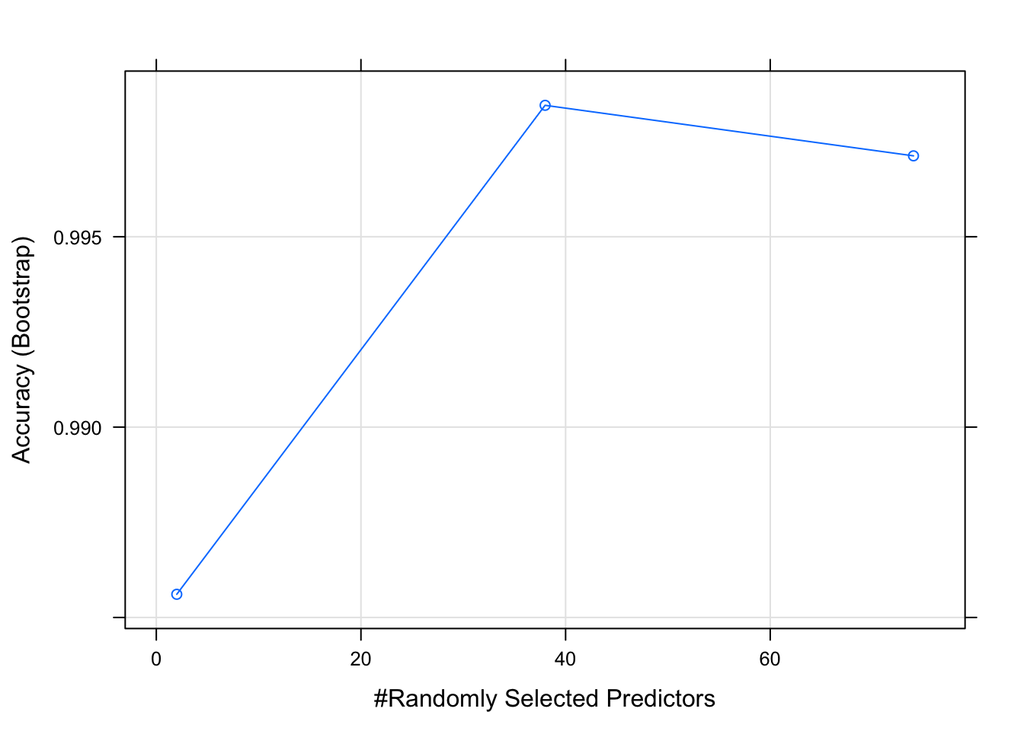

```r
plot(modelfit)   #plotting random forest model
```

```r
library(rattle)
```

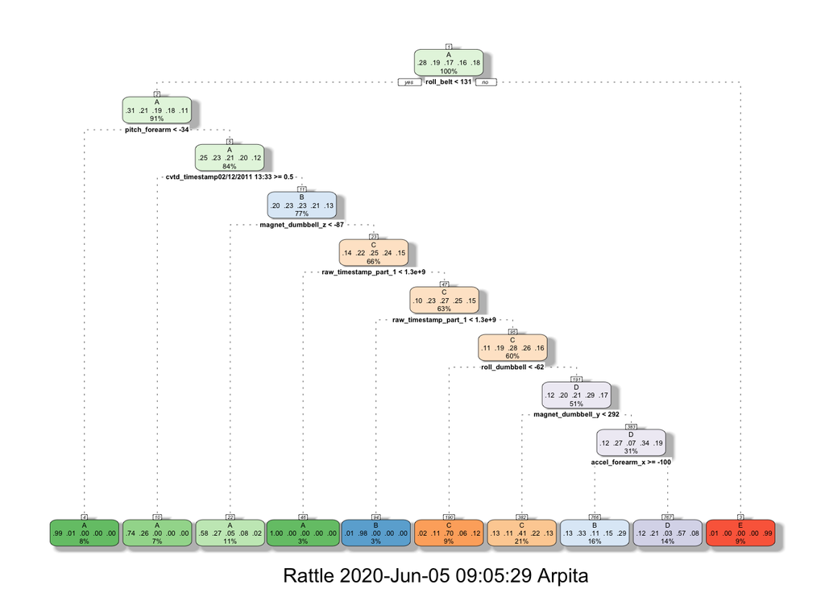

```r
fancyRpartPlot(modelfit_rpart$finalModel)     #plotting cart model
```

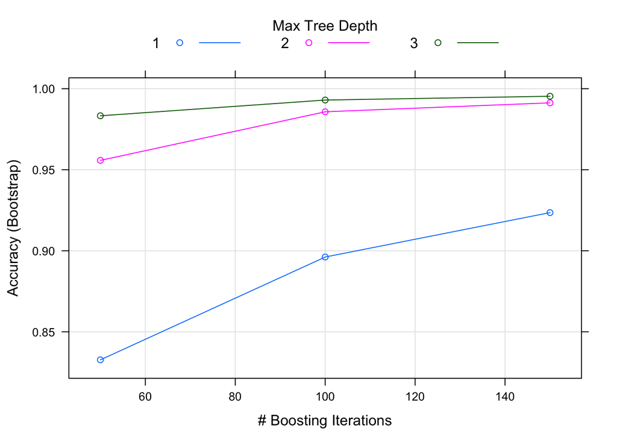

```r
plot(modelfit_gbm)  #plotting gbm model
```

```r
prediction <- predict(modelfit, newdata = validation_set)       #predicting on test set
prediction
prediction_gbm <- predict(modelfit_gbm, newdata = validation_set)
prediction_gbm
prediction_rpart <- predict(modelfit_rpart, newdata = validation_set)
prediction_rpart
```

```r
confmatrix <- confusionMatrix(prediction, validation_set$classe)$overall[1]      #confusion matrix accuracy
confmatrix
```

```
##  Accuracy
## 0.9994902
```

```r
confmatrix_gbm <- confusionMatrix(prediction_gbm, validation_set$classe)$overall[1]
confmatrix_gbm
```

```
##  Accuracy
## 0.9983008
```

```r
confmatrix_rpart <- confusionMatrix(prediction_rpart, validation_set$classe)$overall[1]
confmatrix_rpart
```

```
##  Accuracy
## 0.6061172
```

So, as we can see that random forest model gives us the maximum accuracy.So we will use this model to predict on the test set given after removing missing values from test set.Also, the 5 most important variables according to random forest model are -

[output not shown]

```r
sum(is.na(testing_data))
```

```
## [1] 2000
```

```r
testing_data <- testing_data[ -c(1, 12:35, 49:58, 68:82, 86:100, 102:111, 124:138 ,140:150) ] #removing columns with NA values in test data
testing_data <- testing_data[ -c(11, 24, 33, 36, 49)]
testing_data <- testing_data[ -c(33)]
sum(is.na(testing_data))
```

```
## [1] 0
```

```r
prediction_test <- predict(modelfit, testing_data)
prediction_test
```

```
##  [1] B A B A A E D B A A B C B A E E A B B B
## Levels: A B C D E
```